# R Data Wrangling

Brian Stock

March 28, 2017

Unfortunately you will often need to “clean” or “wrangle” data before you can do an analysis. Let’s practice!

We will look at the U.S. West Coast Annual Bottom Trawl Survey dataset. This is a large, important fishery-independent dataset used to assess fish stocks in the U.S.:

https://data.noaa.gov/dataset/west-coast-groundfish-bottom-trawl-survey-data-annual-west-coast-time-series-groundfish-trawl- https://www.nwfsc.noaa.gov/research/divisions/fram/groundfish/bottom_trawl.cfm

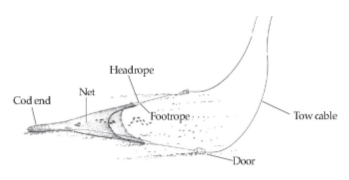

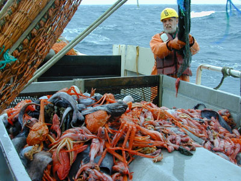

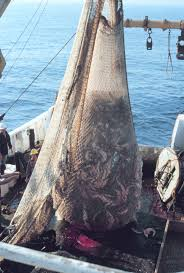

## Our goal

We want to look at the catch of 3 species:

1. What percent of hauls have > 0 catch for each species?
2. Plot the distribution of catches for each species
3. Has catch of each species changed over time?
4. Are catches of the 3 species correlated?

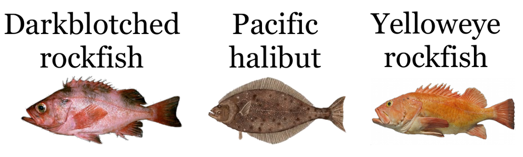

In order to answer our questions, we need to create a clean data frame that looks like:

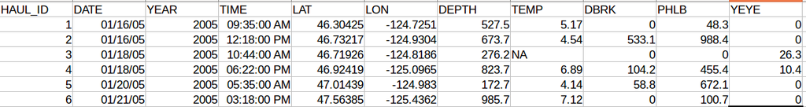

## What data do we have?

We have two separate data files:

- HAUL: information about each time the net went in the water (e.g. time/lat/long in/out, depth, etc.)
- FISH: information about which species and how much of each were caught in each haul

```r
# set working directory to workshop folder with data files
setwd("/home/brian/Documents/Workshops/Mexico fisheries/StatsClass")
# check folder contents
list.files()
# load haul dataset
HAUL <- read.csv("wcann_haul.csv",header=TRUE)
# load fish dataset
FISH <- read.csv("wcann_fish.csv",header=TRUE)
```

```
##  [1] "ANOVA_CPUE.csv"             "ANOVA_CPUE_map.png"
##  [3] "anova_table.png"            "anova_tukey.png"
##  [5] "Brian_1_Intro_Stats.pdf"    "Brian_1_Intro_Stats.pptx"
##  [7] "Brian_2_distributions.html" "Brian_2_distributions.Rmd"
##  [9] "Brian_3_ANOVA.html"         "Brian_3_ANOVA.pdf"
## [11] "Brian_3_ANOVA.pptx"         "Brian_3_ANOVA.Rmd"
## [13] "Brian_4_regression.html"    "Brian_4_regression.Rmd"
## [15] "Brian_5_Rbasics.html"       "Brian_5_Rbasics.Rmd"
## [17] "CrabData.csv"               "data_goal.ods"
## [19] "data_goal.png"              "dateformat.png"
## [21] "LandingsData.csv"           "MexicoTest.docx"
## [23] "MexicoTest.html"            "MexicoTest.RMd"
## [25] "problem13.csv"              "problem15.csv"
## [27] "problem2.csv"               "Rbasics_exercise.pdf"
## [29] "README.md"                  "stretch.jpeg"
## [31] "trawl_net.jpeg"             "trawl.png"
## [33] "trawl_sample.jpg"           "Ttests_normality.rmd"
## [35] "walleye_baitshop.JPG"       "walleye_statue.jpg"
## [37] "wcann_fish.csv"             "wcann_haul.csv"
## [39] "wcgop_species.png"          "westcoastsurvey.png"
## [41] "Whale data.csv"             "whiteseabass.jpg"
## [43] "Yelapa2017Curriculum.pdf"
```

## Explore `HAUL`

```r
dim(HAUL)
```

```
## [1] 12906    16
```

```r
names(HAUL)
```

```
##  [1] "Survey"                           "Survey.Cycle"
##  [3] "Vessel"                           "Cruise.Leg"
##  [5] "Trawl.Id"                         "Trawl.Performance"
##  [7] "Trawl.Date"                       "Trawl.Start.Time"
##  [9] "Best.Latitude..dd."               "Best.Longitude..dd."
## [11] "Best.Position.Type"               "Best.Depth..m."
## [13] "Best.Depth.Type"                  "Trawl.Duration..min."
## [15] "Area.Swept.by.the.Net..hectares." "Temperature.At.the.Gear..degs.C."
```

```r
# 'Trawl.Id' is the trawl number.
# For some reason the dataset is duplicated
length(unique(HAUL$Trawl.Id))
```

```
## [1] 6453
```

```r
# See that 1 = 6454, 2 = 6455, ...
HAUL$Trawl.Id[1]==HAUL$Trawl.Id[6454]
```

```
## [1] TRUE
```

```r
HAUL$Trawl.Id[2]==HAUL$Trawl.Id[6455]
```

```
## [1] TRUE
```

```r
# So only keep the first half of the rows
hauls <- unique(HAUL$Trawl.Id)
n.hauls <- length(hauls)
HAUL <- HAUL[1:n.hauls,]
dim(HAUL)
```

```
## [1] 6453   16
```

#### How many vessels have been used in the survey?

#### Which vessel has done the most hauls?

```r
table(HAUL$Vessel)
```

```
##
##    BJ Thomas Blue Horizon Captain Jack    Excalibur    Ms. Julie
##          148          122          134         1703         1633
##    Noahs Ark        Raven
##         1502         1211
```

#### When was the earliest and latest haul done?

```r
sort(HAUL$Trawl.Date)[1]
```

```
## [1] 10/10/03
## 903 Levels: 10/10/03 10/10/04 10/10/05 10/10/06 10/10/07 ... 9/9/12
```

```r
sort(HAUL$Trawl.Date,decreasing=TRUE)[1]
```

```
## [1] 9/9/12
## 903 Levels: 10/10/03 10/10/04 10/10/05 10/10/06 10/10/07 ... 9/9/12
```

#### What depth is a normal haul at?

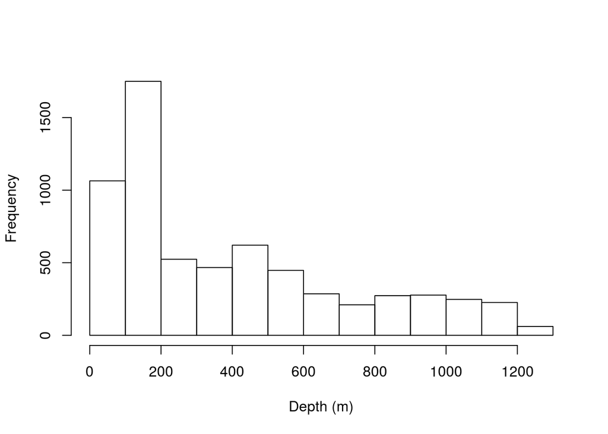

```r
hist(HAUL$Best.Depth..m.,xlab="Depth (m)",main="")
```

## Explore `FISH`

```r
dim(FISH)
```

```
## [1] 106049      4
```

```r
names(FISH)
```

```
## [1] "Trawl.Id"                       "Species"
## [3] "Haul.Weight..kg."               "Individual.Average.Weight..kg."
```

```r
head(FISH)
```

```
##      Trawl.Id                                      Species
## 1 2.00303e+11                           Anoplopoma fimbria
## 2 2.00303e+11                          Antimora microlepis
## 3 2.00303e+11                          Apristurus brunneus
## 4 2.00303e+11                      Bathyagonus nigripinnis
## 5 2.00303e+11 Bathyraja kincaidii (formerly B. interrupta)
## 6 2.00303e+11                        Careproctus melanurus
##   Haul.Weight..kg. Individual.Average.Weight..kg.
## 1           10.800                          1.350
## 2            2.300                          0.115
## 3            4.050                          0.270
## 4            0.005                          0.003
## 5            0.900                          0.900
## 6            0.900                          0.300
```

## Combine `HAUL` and `FISH`

Want to get data frame `dat` where each row is a unique haul, with the following columns:

- HAUL_ID: HAUL$Trawl.Id
- YEAR: have to calculate from DATE
- DATE: HAUL$Trawl.Date
- TIME: HAUL$Trawl.Start.Time
- LAT: latitude, HAUL$Best.Latitude..dd.
- LON: longitude, HAUL$Best.Longitude..dd.
- DEPTH: HAUL$Best.Depth..m.
- TEMP: bottom temperature (at gear), HAUL$Temperature.At.the.Gear..degs.C.
- DBRK: darkblotched rockfish catch in kg (FISH$Species==“Sebastes crameri”)
- PHLB: Pacific halibut catch in kg (FISH$Species==“Hippoglossus stenolepis”)
- YEYE: yelloweye rockfish catch in kg (FISH$Species==“Sebastes ruberrimus”)

```r
# Create empty data frame where each row will be a unique haul
cols <- c("HAUL_ID","YEAR","DATE","TIME","LAT","LON","DEPTH","TEMP","DBRK","PHLB","YEYE")
dat <- matrix(NA, nrow=n.hauls, ncol=length(cols))
dat <- as.data.frame(dat)
names(dat) <- cols
head(dat)
```

```
##   HAUL_ID YEAR DATE TIME LAT LON DEPTH TEMP DBRK PHLB YEYE
## 1      NA   NA   NA   NA  NA  NA    NA   NA   NA   NA   NA
## 2      NA   NA   NA   NA  NA  NA    NA   NA   NA   NA   NA
## 3      NA   NA   NA   NA  NA  NA    NA   NA   NA   NA   NA
## 4      NA   NA   NA   NA  NA  NA    NA   NA   NA   NA   NA
## 5      NA   NA   NA   NA  NA  NA    NA   NA   NA   NA   NA
## 6      NA   NA   NA   NA  NA  NA    NA   NA   NA   NA   NA
```

```r
# Fill in easy columns that are already calculated by haul
dat$HAUL_ID <- HAUL$Trawl.Id
dat$LAT <- HAUL$Best.Latitude..dd.
dat$LON <- HAUL$Best.Longitude..dd.
dat$DEPTH <- HAUL$Best.Depth..m.
dat$TEMP <- HAUL$Temperature.At.the.Gear..degs.C.
```

## Dates and times in R

Dates and times can be a little tricky in R. Let’s explore.

```r
today <- Sys.Date() # get today's date
print(today)
```

```
## [1] "2017-03-25"
```

```r
format(today, format="%B %d %Y") # show in different format
```

```
## [1] "March 25 2017"
```

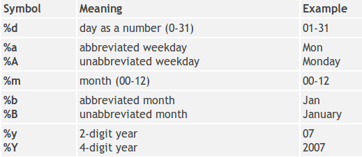

How are the dates coded in `HAUL`?

```r
class(HAUL$Trawl.Date)
```

```
## [1] "factor"
```

```r
head(HAUL$Trawl.Date)
```

```
## [1] 8/31/03 9/1/03  9/1/03  9/1/03  9/1/03  9/2/03
## 903 Levels: 10/10/03 10/10/04 10/10/05 10/10/06 10/10/07 ... 9/9/12
```

We need to convert from a `factor` to a `date`. To do this, we need to tell R what format it is currently

```r
dat$DATE <- as.Date(HAUL$Trawl.Date,format = "%m/%d/%y")
head(dat$DATE)
```

```
## [1] "2003-08-31" "2003-09-01" "2003-09-01" "2003-09-01" "2003-09-01"
## [6] "2003-09-02"
```

Now that we know how to format date objects, we can extract the year from `dat$DATE` to put into `dat$YEAR`:

```r
dat$YEAR <- as.numeric(format(dat$DATE,"%Y"))
head(dat$YEAR)
```

```
## [1] 2003 2003 2003 2003 2003 2003
```

And we can see how many hauls were done each year:

```r
table(dat$YEAR)
```

```
##
## 2003 2004 2005 2006 2007 2008 2009 2010 2011 2012
##  541  471  637  642  688  681  682  713  697  701
```

Times are a bit trickier, we need a new function `as.POSIXct`. For the format codes, see `?strptime`.

How is time currently formatted?

```r
head(HAUL$Trawl.Start.Time)
```

```
## [1] 8/31/03 18:12 9/1/03 6:01   9/1/03 8:45   9/1/03 12:58  9/1/03 15:45
## [6] 9/2/03 5:46
## 6433 Levels: 10/10/03 11:35 10/10/03 15:04 10/10/03 16:32 ... 9/9/12 9:19
```

```r
head(as.character(HAUL$Trawl.Start.Time))
```

```
## [1] "8/31/03 18:12" "9/1/03 6:01"   "9/1/03 8:45"   "9/1/03 12:58"
## [5] "9/1/03 15:45"  "9/2/03 5:46"
```

Then convert to class `POSIXct`:

```r
dat$TIME <- as.POSIXct(as.character(HAUL$Trawl.Start.Time), format = "%m/%d/%y %H:%M", tz="US/Pacific")
attr(dat$TIME, "tzone") <- "US/Pacific"
class(dat$TIME)
```

```
## [1] "POSIXct" "POSIXt"
```

Excellent work! We now only need to add the fish catch columns. Perhaps time for a break… stretch!

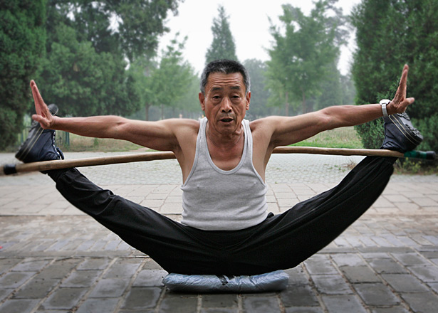

## *If/else* in R

*If* statements are useful to tell R to do something only *if* a condition is true. *Else* will tell R to do if that condition is false.

A simple example:

```r
x <- 1
if(x < 2){
  x <- x + 10
}
print(x)
```

```
## [1] 11
```

See that if `x > 2`, we do not add 10:

```r
x <- 5
if(x < 2){
  x <- x + 10
}
print(x)
```

```
## [1] 5
```

Use *else* to tell R to do something if the condition is FALSE:

```r
x <- 5
if(x < 2){
  x <- x + 10
} else{
  cat("nope... x is NOT < 2")
}
```

```
## nope... x is NOT < 2
```

## *For* loops in R

Computers are good at repeating things. The *for* loop can be used to repeat a set of instructions so you don’t have to copy and paste the same code.

```r
for(i in 1:5){
  print(x + i)
}
```

```
## [1] 6
## [1] 7
## [1] 8
## [1] 9
## [1] 10
```

You can put a for loop inside another for loop. For example, can go through each entry in a matrix:

```r
M <- matrix(1:12, nrow=4, ncol=3)
M
```

```
##      [,1] [,2] [,3]
## [1,]    1    5    9
## [2,]    2    6   10
## [3,]    3    7   11
## [4,]    4    8   12
```

```r
for(r in 1:4){
  for(c in 1:3){
    print(paste0("Row ", r, ", Col ", c, ": ", M[r, c]))
  }
}
```

```
## [1] "Row 1, Col 1: 1"
## [1] "Row 1, Col 2: 5"
## [1] "Row 1, Col 3: 9"
## [1] "Row 2, Col 1: 2"
## [1] "Row 2, Col 2: 6"
## [1] "Row 2, Col 3: 10"
## [1] "Row 3, Col 1: 3"
## [1] "Row 3, Col 2: 7"
## [1] "Row 3, Col 3: 11"
## [1] "Row 4, Col 1: 4"
## [1] "Row 4, Col 2: 8"
## [1] "Row 4, Col 3: 12"
```

## Combine `HAUL` and `FISH`

Now we know about *if* and *for*, we can fill in `dat` row-by-row with the catch of each species in each haul.

```r
# See what DBRK, PHLB, and YEYE look like
head(dat$DBRK)
```

```
## [1] NA NA NA NA NA NA
```

```r
head(dat$PHLB)
```

```
## [1] NA NA NA NA NA NA
```

```r
head(dat$YEYE)
```

```
## [1] NA NA NA NA NA NA
```

```r
# Turn them all into 0 instead of NA
dat$DBRK <- 0
dat$PHLB <- 0
dat$YEYE <- 0
head(dat$DBRK)
```

```
## [1] 0 0 0 0 0 0
```

```r
library(dplyr)
```

```r
i = 3
dat$HAUL_ID[i]
```

```
## [1] 2.00303e+11
```

```r
cur_haul <- filter(FISH,Trawl.Id==dat$HAUL_ID[i])
dim(cur_haul)
```

```
## [1] 19  4
```

```r
dim(cur_haul)[1] # get number of rows in ith haul
```

```
## [1] 19
```

```r
cur_haul # get rows of FISH (species caught) in the ith haul
```

```
##       Trawl.Id                                      Species
## 1  2.00303e+11                           Anoplopoma fimbria
## 2  2.00303e+11                          Atheresthes stomias
## 3  2.00303e+11                     Bathyagonus pentacanthus
## 4  2.00303e+11 Bathyraja kincaidii (formerly B. interrupta)
## 5  2.00303e+11                        Careproctus melanurus
## 6  2.00303e+11                      Glyptocephalus zachirus
## 7  2.00303e+11                           Hydrolagus colliei
## 8  2.00303e+11                          Lycodes cortezianus
## 9  2.00303e+11                            Lycodes diapterus
## 10 2.00303e+11                             Lyopsetta exilis
## 11 2.00303e+11                         Merluccius productus
## 12 2.00303e+11                        Microstomus pacificus
## 13 2.00303e+11                           Ophiodon elongatus
## 14 2.00303e+11                                   Raja rhina
```

[output cut: 25 more lines]

```r
cur_haul$Species # species names only from ith haul
```

```
##  [1] Anoplopoma fimbria
##  [2] Atheresthes stomias
##  [3] Bathyagonus pentacanthus
##  [4] Bathyraja kincaidii (formerly B. interrupta)
##  [5] Careproctus melanurus
##  [6] Glyptocephalus zachirus
##  [7] Hydrolagus colliei
##  [8] Lycodes cortezianus
##  [9] Lycodes diapterus
## [10] Lyopsetta exilis
## [11] Merluccius productus
## [12] Microstomus pacificus
## [13] Ophiodon elongatus
## [14] Raja rhina
## [15] Sebastes alutus
## [16] Sebastes babcocki
## [17] Sebastes crameri
## [18] Sebastes diploproa
## [19] Sebastolobus alascanus
## 424 Levels: Agonidae Agonopsis sterletus ... Zoarcidae
```

```r
# %in% returns TRUE/FALSE: was yelloweye caught in ith haul?
"Sebastes ruberrimus" %in% cur_haul$Species # YEYE
```

```
## [1] FALSE
```

```r
"Sebastes crameri" %in% cur_haul$Species # DBRK
```

```
## [1] TRUE
```

```r
"Hippoglossus stenolepis" %in% cur_haul$Species # PHLB
```

```
## [1] FALSE
```

```r
# filter to only get DBRK row
filter(cur_haul,Species=="Sebastes crameri")
```

```
##      Trawl.Id          Species Haul.Weight..kg.
## 1 2.00303e+11 Sebastes crameri            338.9
##   Individual.Average.Weight..kg.
## 1                          0.962
```

```r
# get only the catch in kg
filter(cur_haul,Species=="Sebastes crameri")$Haul.Weight..kg.
```

```
## [1] 338.9
```

```r
# Now get the catch for each species for each haul
for(i in 1:n.hauls){
    cur_haul <- filter(FISH,Trawl.Id==dat$HAUL_ID[i])
    if("Sebastes ruberrimus" %in% cur_haul$Species) dat$YEYE[i] <- filter(cur_haul,Species=="Sebastes ruberrimus")$Haul.Weight..kg.
    if("Sebastes crameri" %in% cur_haul$Species) dat$DBRK[i] <- filter(cur_haul,Species=="Sebastes crameri")$Haul.Weight..kg.
    if("Hippoglossus stenolepis" %in% cur_haul$Species) dat$PHLB[i] <- filter(cur_haul,Species=="Hippoglossus stenolepis")$Haul.Weight..kg.
}
```

Check that it worked:

```r
head(dat$DBRK)
```

```
## [1]   0.0   0.0 338.9   0.0   0.0   0.0
```

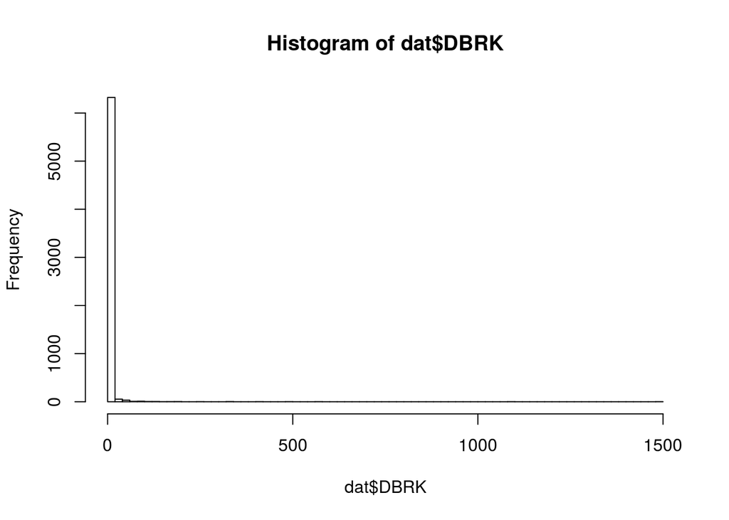

```r
hist(dat$DBRK, breaks=100)
```

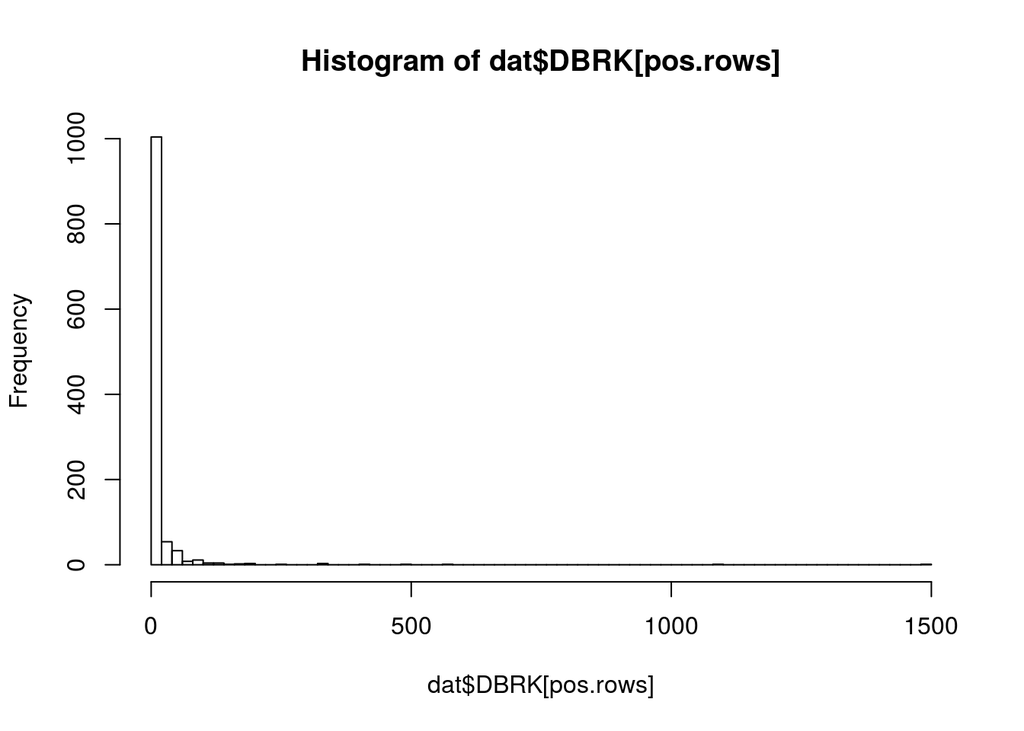

```r
# Plot only positive values
pos.rows <- which(dat$DBRK > 0)
hist(dat$DBRK[pos.rows], breaks=100)
```

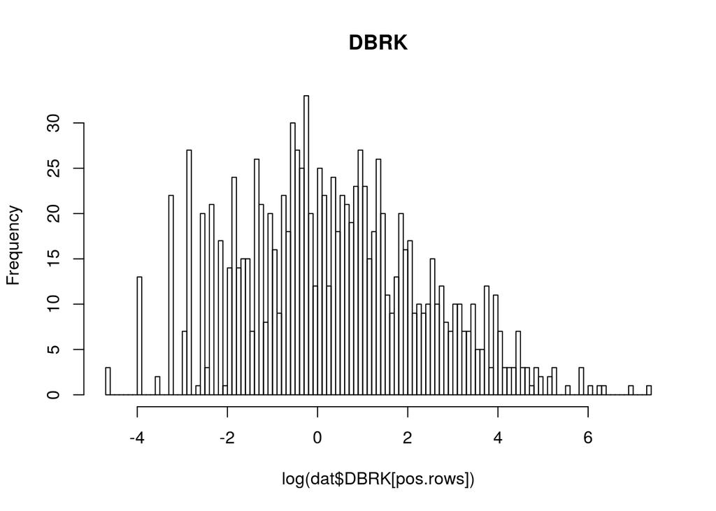

```r
# Extreme right skew. Log transform
hist(log(dat$DBRK[pos.rows]), breaks=100, main="DBRK")
```

Now we can answer our questions! Use for loops to do the calculations for all species at once.

```r
# 1. What percent of hauls have > 0 catch for each species?
species.names <- c("DBRK","PHLB","YEYE")
n.species <- length(species.names)
n.species
```

```
## [1] 3
```

```r
p.catch <- rep(NA,n.species) # store percent catch > 0 for all 3 species
p.catch
```

```
## [1] NA NA NA
```

```r
for(sp in 1:n.species){
  species.names[sp] # get the next species name
  pos.rows <- which(dat[,species.names[sp]] > 0) # which hauls > 0 for that species
  length(pos.rows) # how many hauls > 0 for that species
  n.hauls # total number of hauls
  p.catch[sp] <- length(pos.rows)/n.hauls
}
species.names
```

```
## [1] "DBRK" "PHLB" "YEYE"
```

```r
round(p.catch,3)
```

```
## [1] 0.176 0.081 0.021
```

## Your turn! You can work together or individually.

Use for loops to answer our questions 2-5 for all 3 species. *(Hint)* Open a new plot without erasing the last plot using `dev.new()`.

2. Plot a histogram of *positive* catch for each species (log transform).
3. Plot the time-series of *catch per year* for each species.
4. Plot the time-series of *proportion positive catch* for each species.
5. Identify the haul with the largest catch for each species.

### 2. Histogram of positive catch

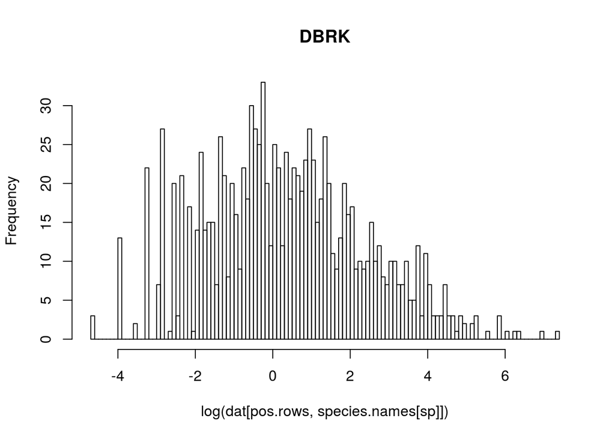

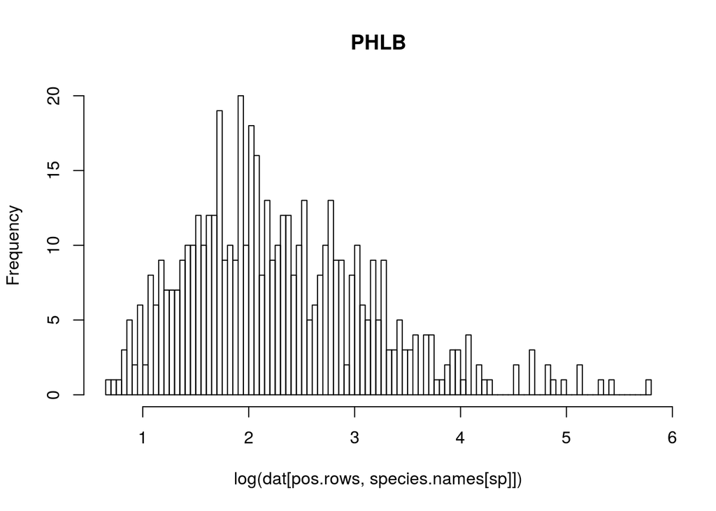

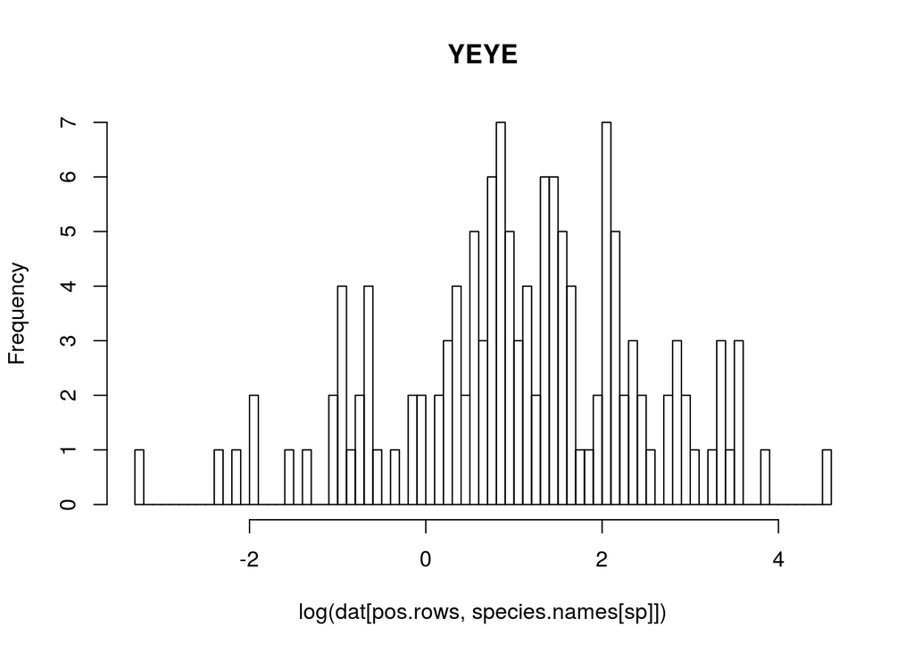

### 3. Time-series of *catch* per year

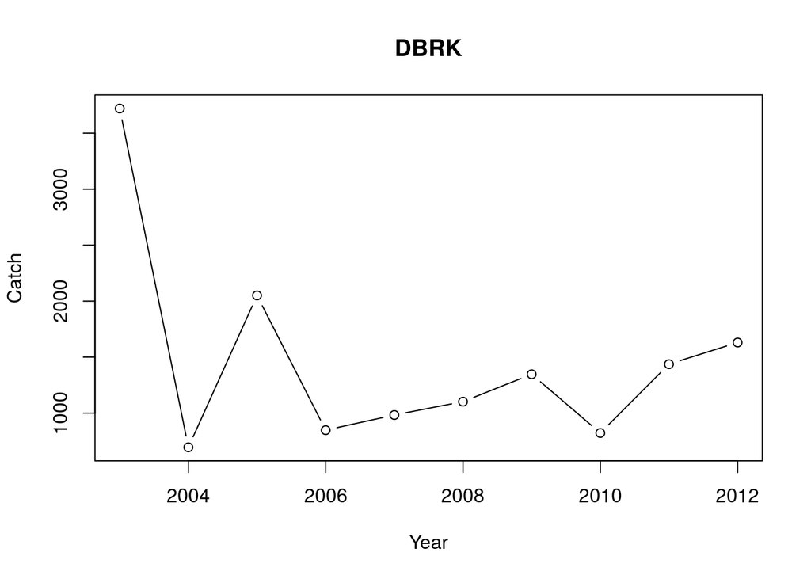

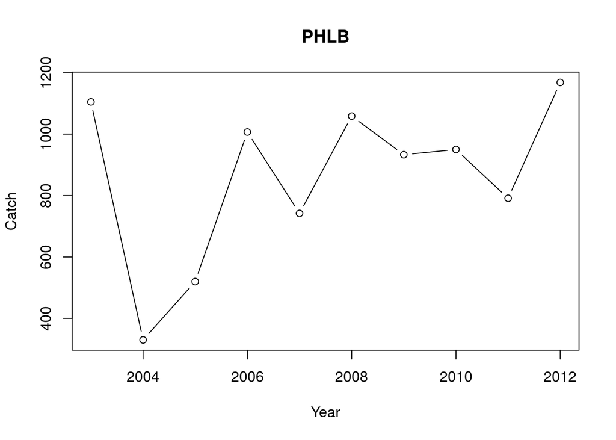

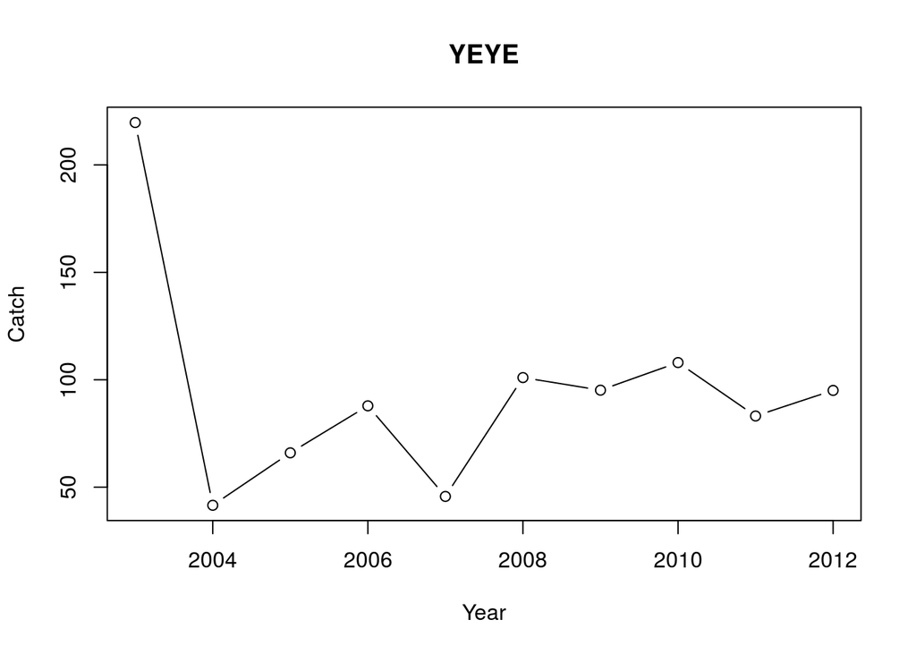

### 4. Time-series of *proportion positive catch* by year

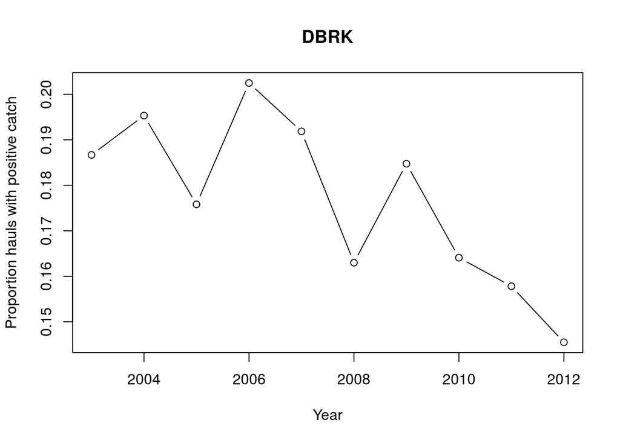

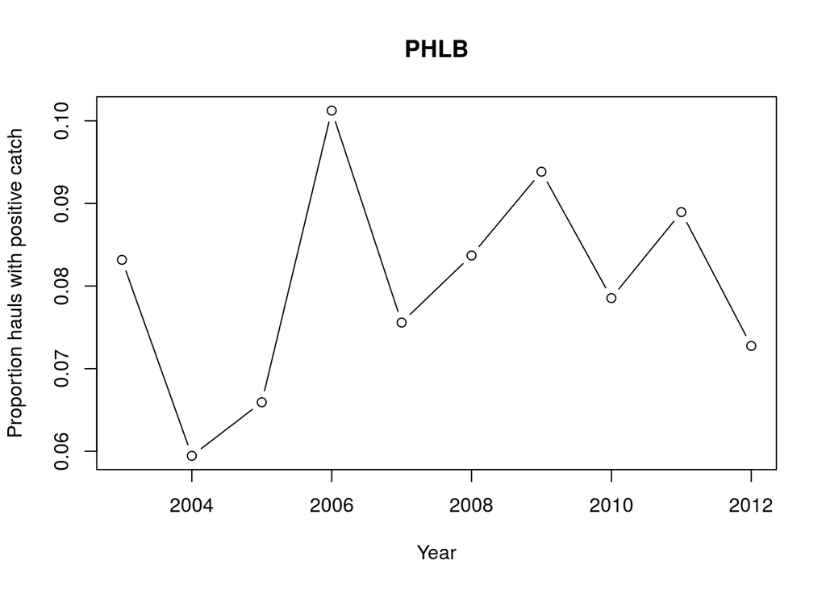

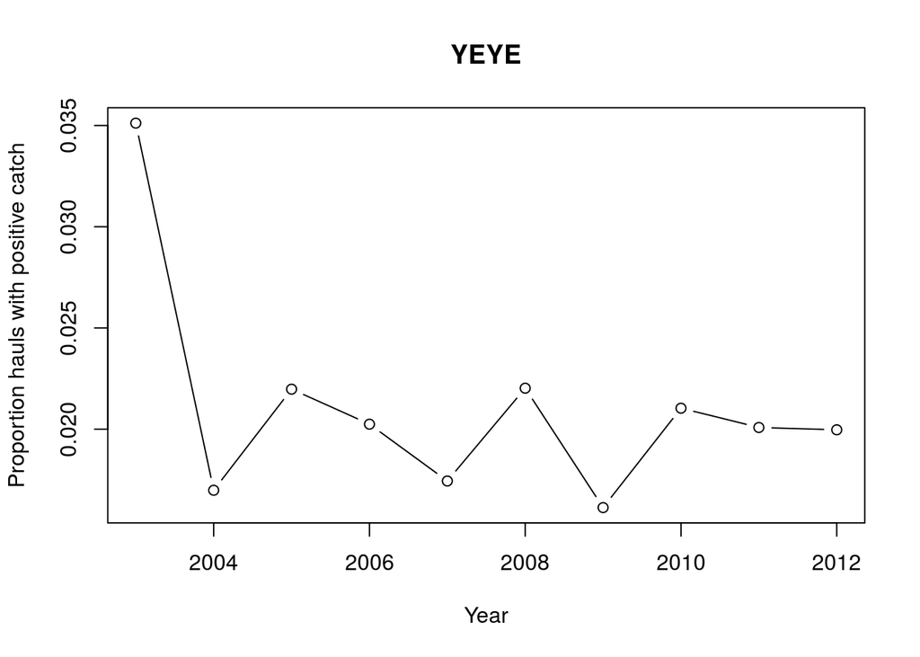

### 5. Haul with largest catch

```
## [1] "DBRK" "PHLB" "YEYE"
```

```
## [1] 1487.70  318.35   96.00
```

```
## [1]   29 6116  464
```